# Anbiopy Library Documentation

*anbiopy* is a python library designed for microbiota data analysis when incorporating other types of variables e.g., anthropometric data.

For installation use:

```
pip install anbiopy
```

This file contains the documentation for all functions available in version 0.1.3

# Recommended libraries to install and use

*anbiopy* uses libraries like pandas, numpy and scikit-bio. However, for data manipulation and visualizations it is useful to import the following libraries

```python
import anbiopy as ab
import pandas as pd
import seaborn as sns
```

# Example data reading

The following are examples of data files that could be analyzed using *anbiopy*.

**Note**: The following files contain previously cleaned data, therefore, there will be no erros associated with incorrect data formatting, missing values, etc.

```python
#Anthropometric data
antro_data = pd.read_csv('anthro_data_clean.meta', sep = '\t')

#OTU observations
otu_data = pd.read_csv('otu_data_clean.otus', sep = '\t')

#Food group intake data
fg_data = pd.read_csv('food_groups_u24h_clean.csv')
fg_data = fg_data.drop(columns = ['Code', 'Codalt', 'r24h'])

#Nutrient intake data
nutrients_data = pd.read_csv('nutrients_data_clean.txt', sep = '\t')
nutrients_data = nutrients_data.drop(columns = ['Codalt'])

#Phylogenetic tree string
tree_file = "tree_data.tre"
with open(tree_file, "r") as f:
    tree = f.read()

#OTU taxonomy data
otu_taxonomy = pd.read_csv('otu_taxonomy.taxonomy', sep = '\t')
```

## Anthropometric data sample

This file contains data related to health outcomes, socioeconomic status, city, age, and others

```python
antro_data.head()
```

|  | ID | city | socioeconomic | sex | age | age_range | HDL | LDL | cholesterol | triglycerides | ... | waist | medicament | fiber | per_protein | per_animal_protein | per_total_fat | per_saturated_fat | per_monoinsaturated_fat | per_polyunsaturated_fat | per_carbohydrates |
| --- | --- | --- | --- | --- | --- | --- | --- | --- | --- | --- | --- | --- | --- | --- | --- | --- | --- | --- | --- | --- | --- |
| 0 | MI_001_H | Medellin | 3 | Male | 36 | 18_40 | 38 | 93.0 | 170 | 195 | ... | 97.6 | No | 19 | 16.15 | 60.53 | 28.40 | 11.01 | 9.88 | 4.82 | 55.47 |
| 1 | MI_002_H | Medellin | 2 | Female | 40 | 18_40 | 52 | 130.0 | 202 | 100 | ... | 89.3 | No | 13 | 13.77 | 66.88 | 29.74 | 11.61 | 10.35 | 6.55 | 56.10 |
| 2 | MI_003_H | Medellin | 3 | Male | 53 | 41_62 | 51 | 119.0 | 185 | 76 | ... | 92.8 | No | 13 | 14.57 | 64.75 | 24.20 | 9.48 | 8.10 | 4.84 | 61.37 |
| 3 | MI_004_H | Medellin | 5 | Male | 58 | 41_62 | 59 | 120.0 | 199 | 99 | ... | 84.7 | Yes | 16 | 19.17 | 65.78 | 28.72 | 11.60 | 10.63 | 5.03 | 51.28 |
| 4 | MI_005_H | Medellin | 3 | Female | 44 | 41_62 | 73 | 63.0 | 159 | 114 | ... | 73.3 | Yes | 21 | 13.86 | 59.40 | 28.40 | 9.91 | 9.66 | 6.92 | 57.50 |

5 rows × 33 columns

## OTU Observations data sample

This file contains OTU observations for each individual

```python
otu_data.head()
```

|  | ID | Otu00001 | Otu00002 | Otu00003 | Otu00004 | Otu00005 | Otu00006 | Otu00007 | Otu00008 | Otu00009 | ... | Otu04757 | Otu04758 | Otu04759 | Otu04760 | Otu04761 | Otu04762 | Otu04763 | Otu04764 | Otu04765 | Otu04766 |
| --- | --- | --- | --- | --- | --- | --- | --- | --- | --- | --- | --- | --- | --- | --- | --- | --- | --- | --- | --- | --- | --- |
| 0 | MI_001_H | 354 | 817 | 50 | 31 | 448 | 547 | 727 | 353 | 2 | ... | 0 | 0 | 0 | 0 | 0 | 0 | 0 | 0 | 0 | 0 |
| 1 | MI_002_H | 168 | 9 | 131 | 3005 | 68 | 10187 | 570 | 2006 | 104 | ... | 0 | 0 | 0 | 0 | 0 | 0 | 0 | 0 | 0 | 0 |
| 2 | MI_003_H | 19 | 174 | 6211 | 79 | 1063 | 0 | 6077 | 1852 | 1471 | ... | 0 | 0 | 0 | 0 | 0 | 0 | 0 | 0 | 0 | 0 |
| 3 | MI_004_H | 264 | 1816 | 159 | 16 | 110 | 4 | 12 | 206 | 0 | ... | 0 | 0 | 0 | 0 | 0 | 0 | 0 | 0 | 0 | 0 |
| 4 | MI_005_H | 0 | 2 | 0 | 12 | 598 | 39 | 0 | 0 | 1 | ... | 0 | 0 | 0 | 0 | 0 | 0 | 0 | 0 | 0 | 0 |

5 rows × 4739 columns

## Food group data sample

This file contains food group intake data from a 24-hour recall survey

```python
fg_data.head()
```

|  | ID | City | Dairy g | Meats g | Eggs g | Beans g | Nuts g | Fruits g | Vegetables g | Cereals g | Tubers g | Fats g | Sugars g | HEI | SCORE_GABAS |
| --- | --- | --- | --- | --- | --- | --- | --- | --- | --- | --- | --- | --- | --- | --- | --- |
| 0 | MI_001_H | Medellin | 0.0001 | 126.0 | 58.0000 | 103.0000 | 0.0001 | 140.0000 | 5.0000 | 295.0 | 15.0000 | 4.0 | 104.0 | 42.3 | 22.3 |
| 1 | MI_002_H | Medellin | 83.0000 | 76.0 | 0.0001 | 0.0001 | 0.0001 | 0.0001 | 35.0000 | 339.0 | 130.0000 | 26.0 | 244.0 | 31.4 | 5.6 |
| 2 | MI_003_H | Medellin | 103.0000 | 90.0 | 0.0001 | 0.0001 | 0.0001 | 96.0000 | 0.0001 | 310.0 | 261.0000 | 15.0 | 336.0 | 37.3 | 28.8 |
| 3 | MI_004_H | Medellin | 322.0000 | 191.0 | 0.0001 | 54.0000 | 0.0001 | 20.0000 | 262.0000 | 150.0 | 0.0001 | 5.0 | 257.0 | 47.1 | 25.0 |
| 4 | MI_005_H | Medellin | 0.0001 | 120.0 | 0.0001 | 0.0001 | 0.0001 | 220.0000 | 323.0000 | 488.0 | 185.0000 | 43.0 | 153.0 | 48.1 | 12.6 |

## Nutrients data sample

This file contains nutrient intake data from a 24-hour recall survey

```python
nutrients_data.head()
```

|  | ID | Calories | Proteins | Total_fat | SFA | MUFA | PUFA | Cholesterol | Carbohydrates | Complex_carbohydrates | ... | Mn | VitA | B1 | B2 | B3 | B5 | B6 | Folate | B12 | VitC |
| --- | --- | --- | --- | --- | --- | --- | --- | --- | --- | --- | --- | --- | --- | --- | --- | --- | --- | --- | --- | --- | --- |
| 0 | MI_001_H | 1771 | 72.45 | 57 | 22.1 | 20.3 | 8.4 | 347 | 247 | 215 | ... | 4.9 | 584 | 0.9 | 1.7 | 17 | 5 | 1.4 | 355 | 7.4 | 139 |
| 1 | MI_002_H | 1908 | 62.39 | 65 | 25.4 | 22.8 | 15.9 | 321 | 270 | 210 | ... | 2.7 | 557 | 0.7 | 1.4 | 14 | 4 | 1.4 | 292 | 7.1 | 88 |
| 2 | MI_003_H | 1802 | 64.29 | 43 | 17.3 | 15.0 | 8.6 | 286 | 293 | 201 | ... | 2.8 | 596 | 1.3 | 1.6 | 24 | 7 | 1.4 | 268 | 7.4 | 178 |
| 3 | MI_004_H | 1573 | 83.09 | 53 | 21.7 | 20.6 | 8.0 | 326 | 190 | 159 | ... | 2.7 | 807 | 1.0 | 1.8 | 16 | 5 | 1.4 | 324 | 7.2 | 154 |
| 4 | MI_005_H | 2211 | 69.64 | 69 | 22.0 | 22.9 | 20.5 | 309 | 324 | 253 | ... | 3.1 | 826 | 1.2 | 1.7 | 17 | 5 | 2.3 | 344 | 7.1 | 313 |

5 rows × 29 columns

## OTU Taxonomy data sample

This file contains the taxonomic classification for each OTU

```python
otu_taxonomy.head()
```

|  | OTU | Size | Taxonomy |
| --- | --- | --- | --- |
| 0 | Otu00001 | 136589 | k__Bacteria;p__Bacteroidetes;c__Bacteroidia;o_... |
| 1 | Otu00002 | 1139018 | k__Bacteria;p__Bacteroidetes;c__Bacteroidia;o_... |
| 2 | Otu00003 | 452087 | k__Bacteria;p__Firmicutes;c__Clostridia;o__Clo... |
| 3 | Otu00004 | 1182065 | k__Bacteria;p__Proteobacteria;c__Gammaproteoba... |
| 4 | Otu00005 | 265091 | k__Bacteria;p__Firmicutes;c__Clostridia;o__Clo... |

# Functions:

## 1. taxonomy_df()

Creates a DataFrame for the taxonomic classification of each OTU, where each column represents one taxon. The main input is the taxonomic classifcation data of each OTU. Something important to consider is that it **must** contain the 'Taxonomy' column, all other columns are maintained and included in the output.

**Parameters:**

- **taxonomic_data**: DataFrame that has a 'Taxonomy' column, which contains the taxonomic classification of the OTU using the following pattern: k__KingdomName;p__PhyluName;c__ClassName;o__OrderName;f__FamilyName;g__GenusName;s__SpeciesName

**Output:** A DataFrame with the complete OTU classification

```python
taxo_df = ab.taxonomy_df(taxonomic_data = otu_taxonomy)
taxo_df.head()
```

|  | OTU | Size | Kingdom | Phylum | Class | Order | Family | Genus | Species |
| --- | --- | --- | --- | --- | --- | --- | --- | --- | --- |
| 0 | Otu00001 | 136589 | Bacteria | Bacteroidetes | Bacteroidia | Bacteroidales | Prevotellaceae | Prevotella | copri |
| 1 | Otu00002 | 1139018 | Bacteria | Bacteroidetes | Bacteroidia | Bacteroidales | Prevotellaceae | Prevotella | copri |
| 2 | Otu00003 | 452087 | Bacteria | Firmicutes | Clostridia | Clostridiales | Ruminococcaceae | Gemmiger | formicilis |
| 3 | Otu00004 | 1182065 | Bacteria | Proteobacteria | Gammaproteobacteria | Enterobacteriales | Enterobacteriaceae | Escherichia | coli |
| 4 | Otu00005 | 265091 | Bacteria | Firmicutes | Clostridia | Clostridiales | Ruminococcaceae | Faecalibacterium | prausnitzii |

## 2. relative_abundaces()

Calculates the relative abundances of each OTU in a OTU observation data frame.

**Parameters:**

- **otus**: OTU observation DataFrame. It **must not** contain an ID column.

**Outpu**: A DataFrame with the relative abundance of each OTU for each sample in decimal form

```python
#Remove ID column from otu data
otu_data_no_id = otu_data.drop(columns = ['ID']).copy()

#Calculate relative abundances
rAbundances = ab.relative_abundances(otus = otu_data_no_id)
rAbundances.head()
```

|  | Otu00001 | Otu00002 | Otu00003 | Otu00004 | Otu00005 | Otu00006 | Otu00007 | Otu00008 | Otu00009 | Otu00010 | ... | Otu04757 | Otu04758 | Otu04759 | Otu04760 | Otu04761 | Otu04762 | Otu04763 | Otu04764 | Otu04765 | Otu04766 |
| --- | --- | --- | --- | --- | --- | --- | --- | --- | --- | --- | --- | --- | --- | --- | --- | --- | --- | --- | --- | --- | --- |
| 0 | 0.015830 | 0.036535 | 0.002236 | 0.001386 | 0.020034 | 0.024461 | 0.032511 | 0.015786 | 0.000089 | 0.030140 | ... | 0.0 | 0.0 | 0.0 | 0.0 | 0.0 | 0.0 | 0.0 | 0.0 | 0.0 | 0.0 |
| 1 | 0.004242 | 0.000227 | 0.003308 | 0.075882 | 0.001717 | 0.257241 | 0.014394 | 0.050655 | 0.002626 | 0.001692 | ... | 0.0 | 0.0 | 0.0 | 0.0 | 0.0 | 0.0 | 0.0 | 0.0 | 0.0 | 0.0 |
| 2 | 0.000635 | 0.005813 | 0.207483 | 0.002639 | 0.035510 | 0.000000 | 0.203007 | 0.061867 | 0.049140 | 0.008585 | ... | 0.0 | 0.0 | 0.0 | 0.0 | 0.0 | 0.0 | 0.0 | 0.0 | 0.0 | 0.0 |
| 3 | 0.030527 | 0.209991 | 0.018386 | 0.001850 | 0.012720 | 0.000463 | 0.001388 | 0.023821 | 0.000000 | 0.044172 | ... | 0.0 | 0.0 | 0.0 | 0.0 | 0.0 | 0.0 | 0.0 | 0.0 | 0.0 | 0.0 |
| 4 | 0.000000 | 0.000151 | 0.000000 | 0.000906 | 0.045166 | 0.002946 | 0.000000 | 0.000000 | 0.000076 | 0.000000 | ... | 0.0 | 0.0 | 0.0 | 0.0 | 0.0 | 0.0 | 0.0 | 0.0 | 0.0 | 0.0 |

5 rows × 4738 columns

## 3. rarefaction()

Performs rarefication on a dataset of OTU observations.

**Parameters:**

- **otus**: OTU observation DataFrame. It **must not** contain an ID column
- **seed (Optional)**: Random seed for replicability. Default value = 23

**Output**: The rarefied OTU dataset as a Numpy ndarray (a matrix)

```python
rarefied_otus = ab.rarefaction(otus = otu_data_no_id,
                              seed = 25)
rarefied_otus
```

```
array([[ 58, 123,   8, ...,   0,   0,   0],
       [ 20,   1,  10, ...,   0,   0,   0],
       [  2,  23, 757, ...,   0,   0,   0],
       ...,
       [ 53, 183,  26, ...,   0,   0,   0],
       [ 26, 444,  14, ...,   0,   0,   0],
       [  5, 228,  51, ...,   0,   0,   0]], shape=(438, 4738))
```

## 4. alpha_diversity()

Calculates the alpha diversity of each individual for a given set of metrics.

**Parameters:**

- **otus**: OTU Observation DataFrame. It can include an ID column
- **metrics**: A String list containing the desired metrics. Supported metrics are: "shannon", "sv-richness", "heip_e", "simpson".
- **includes_id (Optional)**: Boolean that indicates if the pData includes an ID column. Default value = False
- **rarefy (Optional)**: Boolean that indicates if the user desires to perform rarefaction on the dataset before calculating alpha-diversities. Default value = True
- **seed (Optional)**: Random seed for replicability. Default value = 23

**Output**: A DataFrame containing each desired metric for each sample. If the user included an ID column it will also be included and named "Sample_ID"

```python
#Using the otu_data version that has an ID column.
alpha_diversity_test = ab.alpha_diversity(otus = otu_data,
                                         metrics = ["shannon", "sv-richness", "heip_e", "simpson"],
                                         includes_ids = True,
                                         rarefy = True,
                                         seed = 24)

alpha_diversity_test.head()
```

|  | Sample_ID | shannon | sv-richness | heip_e | simpson |
| --- | --- | --- | --- | --- | --- |
| 0 | MI_001_H | 3.943455 | 181 | 0.281092 | 0.959711 |
| 1 | MI_002_H | 3.383301 | 196 | 0.145989 | 0.906731 |
| 2 | MI_003_H | 2.723009 | 73 | 0.197584 | 0.888197 |
| 3 | MI_004_H | 3.652965 | 152 | 0.248933 | 0.934891 |
| 4 | MI_005_H | 3.510033 | 116 | 0.282169 | 0.945057 |

## 5. beta_diversities()

**Parameters:**

- **otus**: OTU Observation DataFrame. I can include an ID column
- **metrics**: A String list containing the desired metrics. Supported metrics are: *"weighted_unifrac"*, *"unweighted_unifrac"*.
- **tree_string**: String that represents the phylogenetic tree of the OTUs
- **includes_id (Optional)**: Boolean that indicates if the pData includes an ID column. Default value = False
- **rarefy (Optional)**: Boolean that indicates if the user desires to perform rarefaction on the dataset before calculating alpha-diversities. Default value = True
- **seed (Optional)**: Random seed for replicability. Default value = 23

**Output**: A list that in each position has the beta diversity values for its corresponding metric. Each position contains a list of the elements in the upper triangular of the NxN beta diveristy (these elements do not include the diagonal). If the complete matrix is needed, use *convert_vector_beta_matrix()*.

```python
beta_diversities_test = ab.beta_diversities(otus = otu_data,
                                            tree_string = tree,
                                            metrics = ["weighted_unifrac", "unweighted_unifrac"],
                                            includes_ids = True,
                                            rarefy = True,
                                            seed = 24)
```

```
Calculating weighted_unifrac
Calculating unweighted_unifrac
```

```python
#Weighted unifrac list
w_unifrac = beta_diversities_test[0]
w_unifrac
```

```
array([0.30885603, 0.29508735, 0.256878  , ..., 0.3116189 , 0.26668125,
       0.3373183 ], shape=(95703,))
```

```python
#Unweighted unifrac list
unw_unifrac = beta_diversities_test[1]
unw_unifrac
```

```
array([0.5579263 , 0.72092254, 0.56324009, ..., 0.66912805, 0.64427651,
       0.7132319 ], shape=(95703,))
```

## 6. convert_vector_beta_matrix()

Based on a list of elements, reconstructs the NxN symmetric matrix from which they come from. This matrix has 0's on the diagonal

**Parameters:**

- **vector**: List of elements

**Output**: A numpy (ndarray) NxN matrix with 0 in its diagonal.

```python
#Reconstruct the weighted unifrac beta diversity matrix
beta_matrix = ab.convert_vector_beta_matrix(w_unifrac)
beta_matrix
```

```
array([[0.        , 0.30885603, 0.29508735, ..., 0.22986532, 0.29045919,
        0.3248279 ],
       [0.30885603, 0.        , 0.35423264, ..., 0.33381695, 0.37646354,
        0.40650801],
       [0.29508735, 0.35423264, 0.        , ..., 0.34565211, 0.36271983,
        0.37810437],
       ...,
       [0.22986532, 0.33381695, 0.34565211, ..., 0.        , 0.3116189 ,
        0.26668125],
       [0.29045919, 0.37646354, 0.36271983, ..., 0.3116189 , 0.        ,
        0.3373183 ],
       [0.3248279 , 0.40650801, 0.37810437, ..., 0.26668125, 0.3373183 ,
        0.        ]], shape=(438, 438))
```

## 7. convert_matrix_vector()

Given a NxN matrix, it creates a list of the elements in its upper triangular, not including the diagonal. This is the function that is used inside *beta_diversites()*

**Parametrs:**

- **matrix**: NxN matrix

**Output**: A numpy list with the elements of the matrix

```python
beta_vector = ab.convert_matrix_vector(beta_matrix)
beta_vector
```

```
array([0.30885603, 0.29508735, 0.256878  , ..., 0.3116189 , 0.26668125,
       0.3373183 ], shape=(95703,))
```

## 8. create_graphic()

Creates different types of graphics depending on parameter input. The type of graphics are explained in the **graphic_type** parameter.

**Parameters:**

- **Y**: Observations of objective variable
- **X**: Observations of explicative variables
- **graphic_type**: Number indicating the type of graphic to be created.
  - 1: Y vs. Numeric X -> Line plot
  - 2: Y vs X pData -> Violin plot
  - 3: Y vs Numeric X (first column) and Categoric X (second column) -> Multiple line plot
- **save_file (Optional)**: Boolean to indicate if the created graph should be saved. Default value = False
- **file_name (Optional)**: String for the file name in case the graphic should be saved. Default value = " "

**Output**: No return value. It prints the image on the cell and saves it if necessary

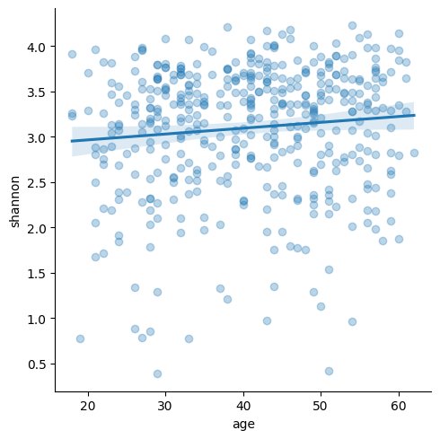

```python
#Test for graphic_type = 1
ab.create_graphic(Y = alpha_diversity_test['shannon'],
                 X = antro_data['age'],
                 graphic_type = 1,
                 save_file = True,
                 file_name = 'LinearTest')
```

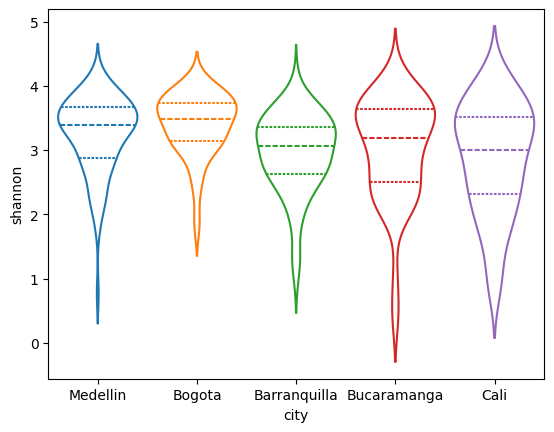

```python
#Test for graphic_type = 2
ab.create_graphic(Y = alpha_diversity_test['shannon'],
                 X = antro_data['city'],
                 graphic_type = 2,
                 save_file = True,
                 file_name = 'ViolinTest')
```

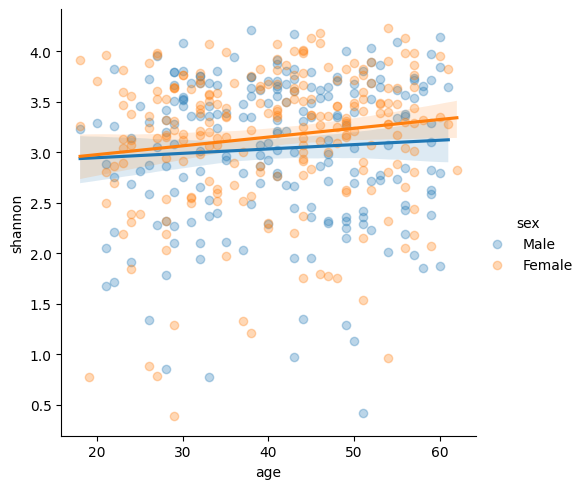

```python
#Test for graphic_type = 3
ab.create_graphic(Y = alpha_diversity_test['shannon'],
                 X = antro_data[['age', 'sex']],
                 graphic_type = 3,
                 save_file = True,
                 file_name = 'MultipleLinearTest')
```

## 9. anova_test()

Creates, runs and evaluates an ANOVA model using selected variables. It validates the 3 assumptions of the ANOVA model: Homocedasticity, Error Normality, Independence. The function call works similar to *aov()* in R, in the sense that it can receive an explicative variable matrix and the user indicates which ones to use.

**Parameters:**:

- **Y**: Observations of the objective variable. This should be a numeric variable
- **data**: DataFrame containing multiple variables.
- **X_columns**: List of strings containing the names of the variables in **data** to be used in the model. All these variables should be categoric.
- **alpha (Optional)**: Alpha value for statistical tests. Default value = 0.05

**Output**: No return value. It prints a message with the following information:

1. ANOVA model results
2. Homocedasticity test and result
3. Error Normality test and result
4. Independe test and result
5. Assumption conclusion.

   5.1 If all assumptions are validated -> Confirmation 5.2 If at least one assumption is not validated -> Indication and possible transformation (depends on number of explicative variables)

```python
# ONE-WAY ANOVA
ab.anova_test(Y = alpha_diversity_test['shannon'],
             data = antro_data,
             X_columns = ['sex'],
             alpha = 0.05)
```

```
Analysis of Variance Table

             Df    Sum Sq  Mean Sq  F value    Pr(>F)
C(sex)      1.0    1.4731   1.4731   2.9201  0.088196
Residual  436.0  219.9560   0.5045      NaN       NaN


Levene's Test for Homocedasticity. H0: There is no hetecedasticity
	Levene statistic: 2.9542092298744724
	Levene statistic p-value: 0.08636403427580945


Shapiro Test for Error Normality. H0: Population is distributed normally
	Shapiro statistic: 0.9237131669644565
	Shapiro statistic p-value: 4.0320648531897236e-14


Durbin-Watson Test for Independence. DW >= 2 indicates no autocorrelation
Durbin-Watson statistic: 1.8672427181482263

The ANOVA Model does not satisfy all assumptions. Consider trying one of the following transformations:
 sqrt(y), ln(y), 1/y, 1/sqrt(y)


Alternatively, you could also try one of the non-parametric tests implemented in the package:
- Kruskall-Wallis H Test (kruskal_wallis_test): Groups can have different number of observations. It tests for same median between groups
- Friedmant Test (friedman_test): If all groups have the same number of observations. It tests for groups having the same distribution
```

```python
## Multiple explicative variables
ab.anova_test(Y = alpha_diversity_test['shannon'],
             data = antro_data,
             X_columns = ['sex', 'city'],
             alpha = 0.05)
```

```
Analysis of Variance Table

             Df    Sum Sq  Mean Sq  F value        Pr(>F)
C(sex)      1.0    1.4731   1.4731   3.1392  7.713572e-02
C(city)     4.0   17.2325   4.3081   9.1805  3.982385e-07
Residual  432.0  202.7235   0.4693      NaN           NaN


Levene's Test for Homocedasticity. H0: There is no hetecedasticity
	Levene statistic: 4.236827663798388
	Levene statistic p-value: 2.8298197108443854e-05


Shapiro Test for Error Normality. H0: Population is distributed normally
	Shapiro statistic: 0.946906576944034
	Shapiro statistic p-value: 2.011530187219779e-11


Durbin-Watson Test for Independence. DW >= 2 indicates no autocorrelation
Durbin-Watson statistic: 2.0200816233867687

The ANOVA Model does not satisfy all assumptions. Consider trying one of the following transformations:
 sqrt(y), ln(y), 1/y, 1/sqrt(y)
```

## 10. multi_level_factors()

For a given objective variable, identifies possible important predictors at different taxonomic levels using Random Forest predicting models. It produces a grid of the most important predictors at each taxonomic level.

Basic logic of execution:

1. For each selected taxonomic level:

   1.1 Groups all OTU observations based on their group within the taxonomic level

   1.2 Creates a RF model using the grouped OTU observations. Be default all RF models are created using sqrt(No. Columns) variables

   1.3 Selected the top **max_rows** groups and includes them in the level's plot.
2. Returns the list of importances for each level

**Parameters**:

- **otus**: DataFrame of OTU observations
- **otu_taxonomy**: DataFrame of taxonomic classification of each OTU. It must contain the same columns as the output of *taxonomy_df()* i.e., it must have Kingdom, Phylum,..., columns.
- **Y**: Observations of the objective variable
- **Y_name**: Name of the objective variable, for the title of the plots.
- **levels**: List of strings containing the taxonomic levels to be used. Supported values are "Kingdom", "Phylum", "Class", "Order", "Family", "Genus", "Species"
- **classification (Optional)**: Boolean to indicate if the predicting task is classification or not. Default value = False
- **includes_ids (Optional)**: Boolean to indicate if **otus** contains an ID column. Default value = False
- **max_rows (Optional)**: Number of top predictors to include in each plot. Default value = 10
- **relatve (Optional)**: Boolean to indicate if relative abundances should be calculated for **otus**. Default value = True
- **seed (Optional)**: Randon seed for replicability of results. Default value = 23
- **save_file (Optional)**: Boolean to indicate if the final plot should be saved. Defalut value = False
- **file_name (Optional)**: String for the file name of the image should it be saved

**Ouputs**

- Prints the grid of plots. If indicated, saves the grid of plots.
- Returns a list of DataFrames, each one corresponding to its respective pLevels value. Each DataFrame contains the complete table of Predictor-Importance values

```
Estimating model for Class
Estimating model for Order
Estimating model for Family
Estimating model for Genus
```

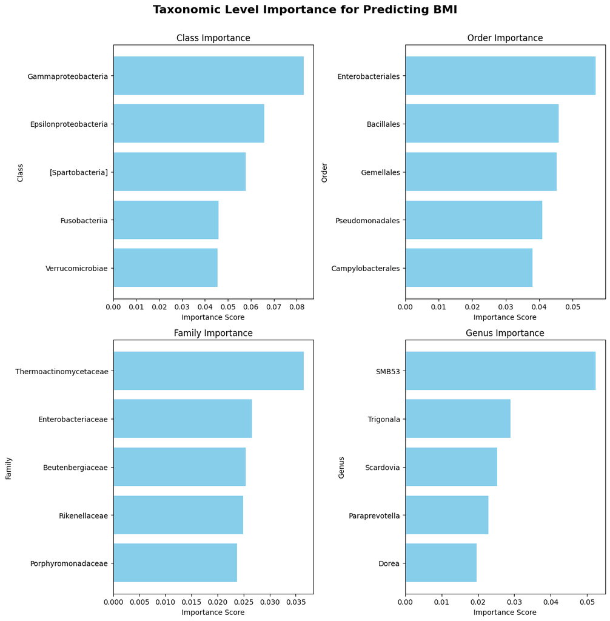

```python
#Important factos for BMI (regression task) at levels Class, Order, Family, Genus
multiple_predictors_test = ab.multi_level_factors(otus = otu_data,
                                                    otu_taxonomy = taxo_df,
                                                    Y = antro_data['bmi'],
                                                    Y_name = "BMI",
                                                    levels = ['Class', 'Order', 'Family', 'Genus'],
                                                    classification = False,
                                                    includes_ids = True,
                                                    max_rows = 5,
                                                    relative = True,
                                                    seed = 24,
                                                    save_file = True,
                                                    file_name = "multiple_factor_test")
```

```python
#All predictors for Order Taxon (second inputed level)
multiple_predictors_test[1].head()
```

|  | Order | Importance |
| --- | --- | --- |
| 2 | Enterobacteriales | 0.056930 |
| 13 | Bacillales | 0.045866 |
| 20 | Gemellales | 0.045302 |
| 22 | Pseudomonadales | 0.040965 |
| 24 | Campylobacterales | 0.038083 |

## 11. single_specific_level_factors()

Specialization of *multi_level_factors()*. Instead of identifying important factors at different taxonomic levels, it identifies important OTUs, belonging to a single group of a taxonomic level, for predicting an objective variable. It produces a plot of important OTUs

**Parameters**:

- **otus**: DataFrame of OTU observations
- **otu_taxonomy**: DataFrame of taxonomic classification of each OTU. It must contain the same columns as the output of *taxonomy_df()* i.e., it must have Kingdom, Phylum,..., columns.
- **Y**: Observations of the objective variable
- **Y_name**: Name of the objective variable, for the title of the plots.
- **level**: Taxonomic level to be used. Supported values are "Kingdom", "Phylum", "Class", "Order", "Family", "Genus", "Species"
- **specific**: Specific group to be used.
- **classification (Optional)**: Boolean to indicate if the predicting task is classification or not. Default value = False
- **includes_ids (Optional)**: Boolean to indicate if **otus** contains an ID column. Default value = False
- **max_rows (Optional)**: Number of top predictors to include in each plot. Default value = 10
- **reltive (Optional)**: Boolean to indicate if relative abundances should be calculated for **tous**. Default value = True
- **seed (Optional)**: Randon seed for replicability of results. Default value = 23
- **save_file (Optional)**: Boolean to indicate if the final plot should be saved. Defalut value = False
- **file_name (Optional)**: String for the file name of the image should it be saved

**Ouputs**

- Prints the plot and saves it if necessary
- Returns the DataFrame containing all OTU-Importance values

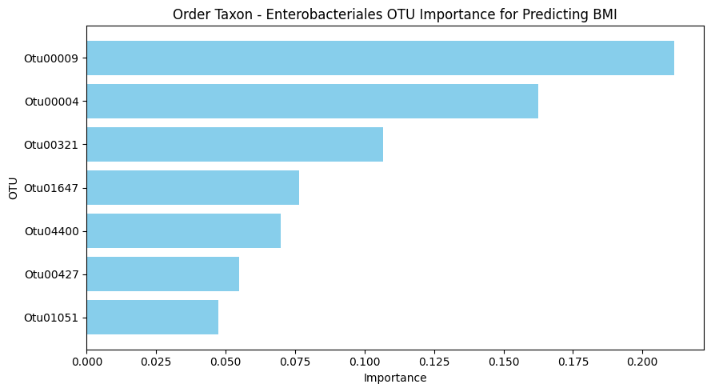

```python
#Important factos for BMI (regression task) at level Order, group Enterobacteriales
single_specific_test = ab.single_specific_level_factors(otus = otu_data,
                                                       otu_taxonomy = taxo_df,
                                                       Y = antro_data['bmi'],
                                                       Y_name = "BMI",
                                                       level = 'Order',
                                                       specific = 'Enterobacteriales',
                                                       classification = False,
                                                       includes_ids = True,
                                                       max_rows = 7,
                                                       relative = True,
                                                       seed = 24,
                                                       save_file = True,
                                                       file_name= 'single_specific_test')
```

```python
#Complete importance DF
single_specific_test.head()
```

|  | OTU | Importance |
| --- | --- | --- |
| 1 | Otu00009 | 0.211511 |
| 0 | Otu00004 | 0.162467 |
| 2 | Otu00321 | 0.106736 |
| 8 | Otu01647 | 0.076405 |
| 35 | Otu04400 | 0.069870 |

## 12. multiple_specific_level_factors()

Exact same logic as *single_specific_level_factors()*, however, it allows for multiple groups within a specific taxonomic level.

**Parameters**:

- **otus**: DataFrame of OTU observations
- **otu_taxonomy**: DataFrame of taxonomic classification of each OTU. It must contain the same columns as the output of *taxonomy_df()*
- **Y**: Observations of the objective variable
- **Y_name**: Name of the objective variable, for the title of the plots.
- **level**: Taxonomic level to be used. Supported values are "Kingdom", "Phylum", "Class", "Order", "Family", "Genus", "Species"
- **specifics**: List of names of groups to be used.
- **classification (Optional)**: Boolean to indicate if the predicting task is classification or not. Default value = False
- **includes_ids (Optional)**: Boolean to indicate if **pOtu** contains an ID column. Default value = False
- **max_rows (Optional)**: Number of top predictors to include in each plot. Default value = 10
- **relative (Optional)**: Boolean to indicate if relative abundances should be calculated for **pOtu**. Default value = True
- **seed (Optional)**: Randon seed for replicability of results. Default value = 23
- **save_file (Optional)**: Boolean to indicate if the final plot should be saved. Defalut value = False
- **file_name (Optional)**: String for the file name of the image should it be saved

**Ouputs**

- Prints the plot and saves it if necessary
- Returns the DataFrame containing all OTU-Importance values

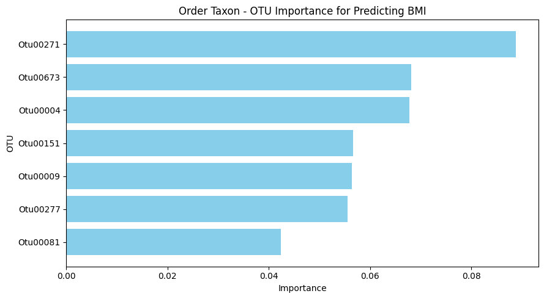

```python
#Important factos for BMI (regression task) at level Order, groups Enterobacteriales, Bacillales
multiple_specific_test = ab.multiple_specific_level_factors(otus = otu_data,
                                                       otu_taxonomy = taxo_df,
                                                       Y = antro_data['bmi'],
                                                       Y_name = "BMI",
                                                       level = 'Order',
                                                       specifics = ['Enterobacteriales', 'Bacillales'],
                                                       classification = False,
                                                       includes_ids = True,
                                                       max_rows = 7,
                                                       relative = True,
                                                       seed = 24,
                                                       save_file = True,
                                                       file_name= 'multiple_specific_test')
```

```python
#Complete importance DF
multiple_specific_test.head()
```

[output not shown]

## 13. friedman_test()

Non-parametric statistical test. It tests if the distribution of an objective variable is the same between different groups.

**Requirements:**

- Only 1 explicative variable
- All groups must have the same number of observations
- At least 3 groups

**Parameters:**

- **Y**: Observations of the objective variable. Must be numeric
- **X**: Observations of the explicative variable. Must be categoric
- **alpha (Optional)**: Alpha value for statistical tests. Defalut value = 0.05

**Outputs**: No return value. It prints the result of the test

```python
#Data preparation for same number of observations of each group
data_bog = antro_data[antro_data['city'] == 'Bogota'].head(50)
data_med = antro_data[antro_data['city'] == 'Medellin'].head(50)
data_baq = antro_data[antro_data['city'] == 'Barranquilla'].head(50)
friedman_data = pd.concat([data_bog, data_med, data_baq], axis = 0)

#Select the alpha diversity values for those individuals
friedman_alpha_data = alpha_diversity_test[alpha_diversity_test['Sample_ID'].isin(friedman_data['ID'])]
```

```python
#Friedmant test using data that complies with its requirements
ab.friedman_test(Y = friedman_alpha_data['shannon'],
                X = friedman_data['city'],
                alpha = 0.05)
```

```
Friedman test result, using alpha = 0.05
Null Hipothesis: All groups have the same distribution
  Friedman Statistic: 16.0
  p-value: 0.0003
The p-value is lower than alpha, therefore, the null hipothesis is rejected
```

## 14. kruskal_wallis_test()

Non-parametric statistical test. It tests if the median of an objective variable is the same between different groups.

**Requirements:**

- Only 1 explicative variable

**Parameters:**

- **Y**: Observations of the objective variable. Must be numeric
- **X**: Observations of the explicative variable. Must be categoric
- **alpha (Optional)**: Alpha value for statistical tests. Defalut value = 0.05

**Outputs**: No return value. It prints the result of the test

```python
ab.kruskal_wallis_test(Y = alpha_diversity_test['shannon'],
                X = antro_data['city'],
                alpha = 0.05)
```

```
Krukall-Wallis-H test result, using alpha = 0.05
Null Hipothesis: The population median of all the groups are equal
  Kruskall-Wallis-H Statistic: 34.3447
  p-value: 0.0
The p-value is lower than alpha, therefore, the null hipothesis is rejected
```

## 15. tax_breakdown()

Shows the taxonomic breakdown of a list of OTUs. Useful for observing the distribution of OTUs

**Parameters**

- **otu_taxonomy**: DataFrame of taxonomic classification of each OTU. It must contain the same columns as the output of *taxonomy_df()* i.e., it must have Kingdom, Phylum,..., columns.
- **otu_list**: List of OTUs to be used.
- **max_depth**: Maximum depth to print. Supported values are "Kingdom", "Phylum", "Class", "Order", "Family", "Genus", "Species". Default value = "" (it goes to "Species")

**Output**: No return value. It prints the taxonomic breakdown, where each tabulation represents a different taxon

```python
#Test OTU list (level Order, groups Enterobacteriales, Bacillales)
#These were the OTUs used for the multiple_specific_level_factors() test
otus = multiple_specific_test['OTU'].to_list()
```

```python
#Tax breakdown (maximum depth of Family)
ab.tax_breakdown(otu_taxonomy = taxo_df,
                 otu_list = otus,
                 max_depth = 'Family')
```

```
-Bacteria: 114
	-Proteobacteria: 42
		-Gammaproteobacteria: 42
			-Enterobacteriales: 42
				-Enterobacteriaceae: 42
	-Firmicutes: 72
		-Bacilli: 72
			-Bacillales: 72
				-[Thermicanaceae]: 20
				-Paenibacillaceae: 13
				-Thermoactinomycetaceae: 9
				-Staphylococcaceae: 3
				-Bacillaceae: 23
				-Listeriaceae: 1
				-Planococcaceae: 2
				-Alicyclobacillaceae: 1
```

## 16. create_level_df()

Creates a DataFrame of grouped OTU values for each group at a specific taxonomic level. This function is used in *multi_level_factors()*

**Parameters**:

- **otus**: OTU DataFrame. It must not contain an ID column
- **otu_taxonomy**: DataFrame of taxonomic classification of each OTU. It must contain the same columns as the output of *taxonomy_df()* i.e., it must have Kingdom, Phylum,..., columns.
- **level**: Taxonomic level for grouping. Supported values are "Kingdom", "Phylum", "Class", "Order", "Family", "Genus", "Species".

```python
#Test for creating the grouped total observations of each group in Class level
#Using the otu data without id
create_level_test = ab.create_level_df(otus = otu_data_no_id,
                   otu_taxonomy = taxo_df,
                   level = 'Class')
create_level_test.head()
```

|  | Bacteroidia | Clostridia | Gammaproteobacteria | Verrucomicrobiae | Actinobacteria | Methanobacteria | Coriobacteriia | Erysipelotrichi | Bacilli | Mollicutes | ... | Aquificae | [Spartobacteria] | Chlamydiia | Chloroflexi | Phycisphaerae | Solibacteres | PBS-25 | [Saprospirae] | Oscillatoriophycideae | Chthonomonadetes |
| --- | --- | --- | --- | --- | --- | --- | --- | --- | --- | --- | --- | --- | --- | --- | --- | --- | --- | --- | --- | --- | --- |
| 0 | 2052 | 14111 | 373 | 548 | 754 | 256 | 2203 | 14 | 703 | 1211 | ... | 0 | 0 | 0 | 0 | 0 | 0 | 0 | 0 | 0 | 0 |
| 1 | 896 | 16387 | 3111 | 10192 | 647 | 3745 | 1854 | 617 | 401 | 1435 | ... | 0 | 0 | 0 | 0 | 0 | 0 | 0 | 0 | 0 | 0 |
| 2 | 211 | 14529 | 1633 | 0 | 6336 | 0 | 3547 | 499 | 3151 | 1 | ... | 0 | 0 | 0 | 0 | 0 | 0 | 0 | 0 | 0 | 0 |
| 3 | 2513 | 4370 | 229 | 4 | 103 | 1 | 523 | 440 | 245 | 46 | ... | 0 | 0 | 0 | 0 | 0 | 0 | 0 | 0 | 0 | 0 |
| 4 | 3216 | 8671 | 84 | 39 | 61 | 1 | 677 | 69 | 147 | 8 | ... | 0 | 0 | 0 | 0 | 0 | 0 | 0 | 0 | 0 | 0 |

5 rows × 55 columns